# Selecting right base graph

principles

Rcode

example

Multiple examples and code from the graphics principles cheatsheet section: selecting the right base graph.

Graphics principles https://graphicsprinciples.github.io/  
2020-12-12

Consider if a standard graph can be used by identifying suitable designs based on the: (i) purpose (i.e. message to be conveyed or question to answer) and (ii) data (i.e. variables to display). In this post we provide multiple examples and code from the [graphics principles cheatsheet](https://github.com/GraphicsPrinciples/CheatSheet/blob/master/NVSCheatSheet.pdf) section: *selecting the right base graph*.

## Deviation (i.e. change from baseline)

Example graphs for displaying deviations from a common reference point or baseline include line plots displaying change from baseline or a diverging barchart such as a waterfall plot.

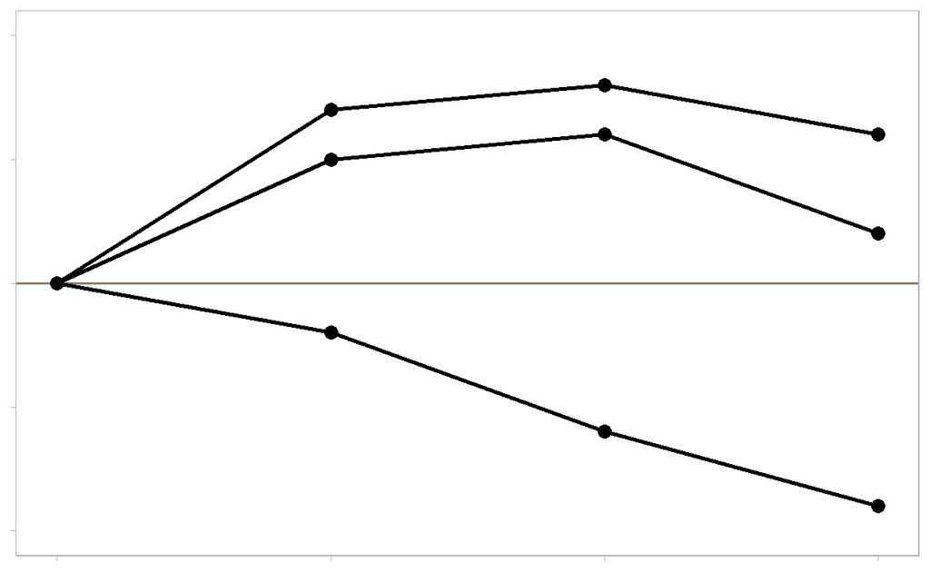

Figure 1: Line plot displaying change over time from a fixed baseline. This is often called a spaghetti or patient profile plot.

```
# generate data and plot with a minimal theme
tibble(
  trt = rep(c("Dose 1", "Dose 2", "Dose 3"), each = 4),
  visit = rep(c(1, 2, 3, 4), 3),
  response = c(0, 0.7, 0.8, 0.6,
               0, 0.5, 0.6, 0.2,
               0, -0.2, -0.6, -0.9)
) %>%
  ggplot(aes(x = visit, y = response, group = trt)) +
  geom_hline(
    yintercept = 0,
    colour = "wheat4",
    linetype = 1,
    size = 0.6
  ) +
  geom_point(size = 3) +
  geom_line(size = 1) +
  scale_y_continuous(limits = c(-1, 1), breaks = c(-1,-0.5, 0, 0.5, 1)) +
  theme(
    legend.position = "none",
    axis.title.y = element_blank(),
    axis.text.y = element_blank(),
    axis.title.x = element_blank(),
    axis.text.x = element_blank(),
    panel.grid.minor = element_blank(),
    panel.grid.major = element_blank()
  )
```

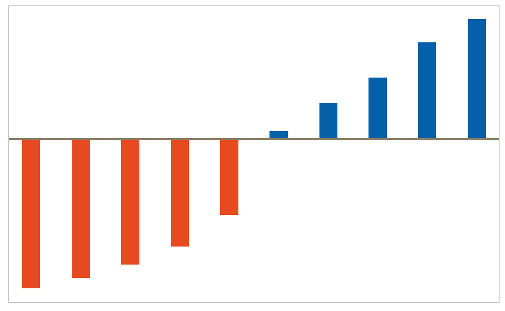

Figure 2: Waterfall or diverging bar chart.

```
## generate data
tibble(x = 1:10,
       ratio = sort(runif(10, 0, 2))) %>%
  mutate(col_flag = if_else(ratio > 1, 1, 0)) %>%
  ggplot(aes(color = factor(col_flag))) +
  geom_segment(aes(
    x = x,
    xend = x,
    y = 1,
    yend = ratio
  ), size = 8) +
  geom_hline(
    yintercept = 1,
    colour = "wheat4",
    linetype = 1,
    size = 1
  ) +
  ggColor(color.hues = c(2, 1)) +
  theme(
    panel.grid.minor = element_blank(),
    panel.grid.major = element_blank(),
    axis.ticks = element_blank(),
    axis.text = element_blank(),
    legend.position = "none",
    axis.title.x = element_blank(),
    axis.title.y = element_blank()
  )
```

# Correlation

For displaying the relationship between them two or more variables, x-y displays such as scatter plots and heatmaps are useful starting points.

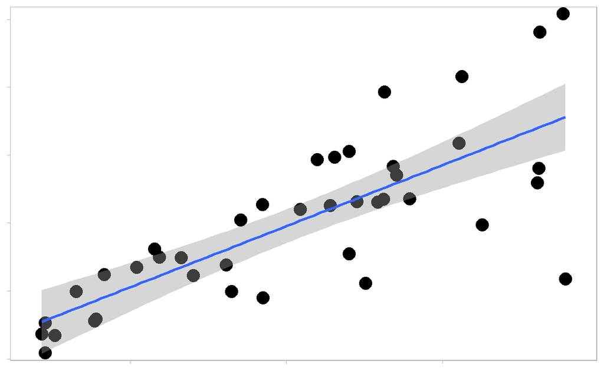

Figure 3: Scatter plot with a regression line

```
tibble(cause = c(runif(40, 1, 10)),
       effect = cause * (rnorm(40, 2, 0.5)) + rnorm(40, 0, 1)
       ) %>%
  ggplot(aes(x = cause, y = effect)) +
  geom_point(size = 4.5,
             shape = 16,
             position = "jitter") +
  geom_smooth(method = "lm") +
  scale_y_continuous(expand = c(0, 0.5)) +
  scale_x_continuous(expand = c(0, 0.5)) +
  theme(
    panel.grid = element_blank(),
    legend.position = "none",
    axis.title.x = element_blank(),
    axis.text.x = element_blank(),
    axis.title.y = element_blank(),
    axis.text.y = element_blank()
  )
```

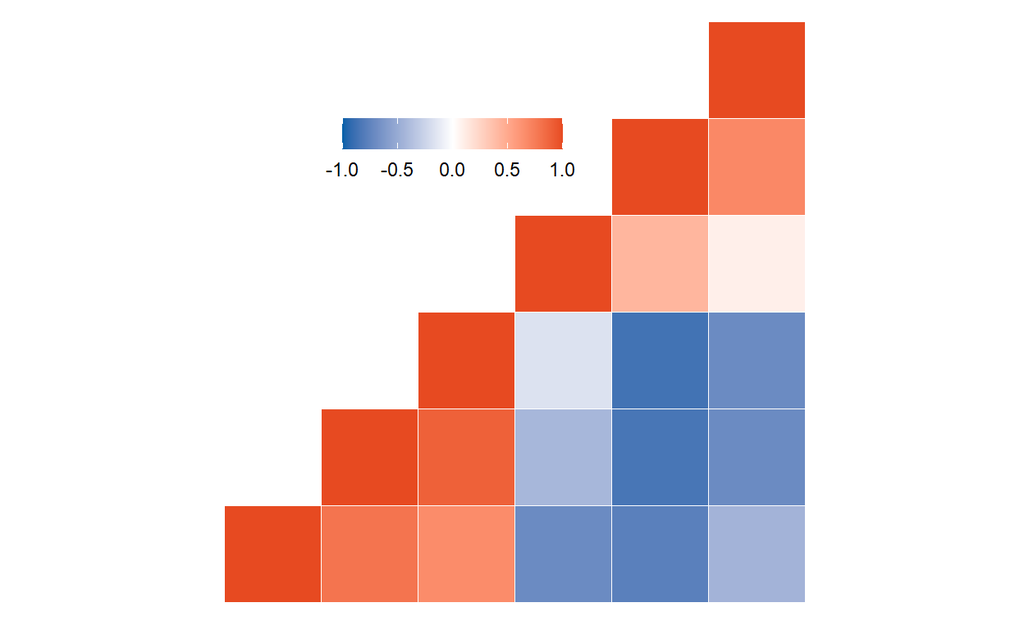

Figure 4: Correlation heatmap.

```
mydata <- mtcars[, c(1, 3, 4, 5, 6, 7)]
cormat <- round(cor(mydata), 2)
melted_cormat <- melt(cormat)

# Get lower triangle of the correlation matrix
get_lower_tri <- function(cormat) {
  cormat[upper.tri(cormat)] <- NA
  return(cormat)
}

# Get upper triangle of the correlation matrix
get_upper_tri <- function(cormat) {
  cormat[lower.tri(cormat)] <- NA
  return(cormat)
}

upper_tri <- get_upper_tri(cormat)
melted_cormat <- melt(upper_tri, na.rm = TRUE)

reorder_cormat <- function(cormat) {
  # Use correlation between variables as distance
  dd <- as.dist((1 - cormat) / 2)
  hc <- hclust(dd)
  cormat <- cormat[hc$order, hc$order]
}

# Reorder the correlation matrix
cormat <- reorder_cormat(cormat)
upper_tri <- get_upper_tri(cormat)

# Melt the correlation matrix
melted_cormat <- melt(upper_tri, na.rm = TRUE)

# Create a ggheatmap
ggplot(melted_cormat, aes(Var2, Var1, fill = value)) +
  geom_tile(color = "white") +
  scale_fill_gradient2(
    low = Novartis.Color.Palette[1, 1],
    high = Novartis.Color.Palette[1, 2],
    mid = "white",
    midpoint = 0,
    limit = c(-1, 1),
    space = "Lab"
  ) +
  coord_fixed() +
  guides(fill = guide_colorbar(barwidth = 7, barheight = 1)) +
  theme(
    axis.text = element_blank(),
    axis.title.x = element_blank(),
    axis.title.y = element_blank(),
    legend.title = element_blank(),
    panel.grid = element_blank(),
    panel.border = element_blank(),
    panel.background = element_blank(),
    axis.ticks = element_blank(),
    legend.justification = c(1, 0),
    legend.position = c(0.6, 0.7),
    legend.direction = "horizontal"
  )
```

# Ranking

Bar charts and dot plots are effective for disaplying quantities ordered highest to lowest (or vice versa).

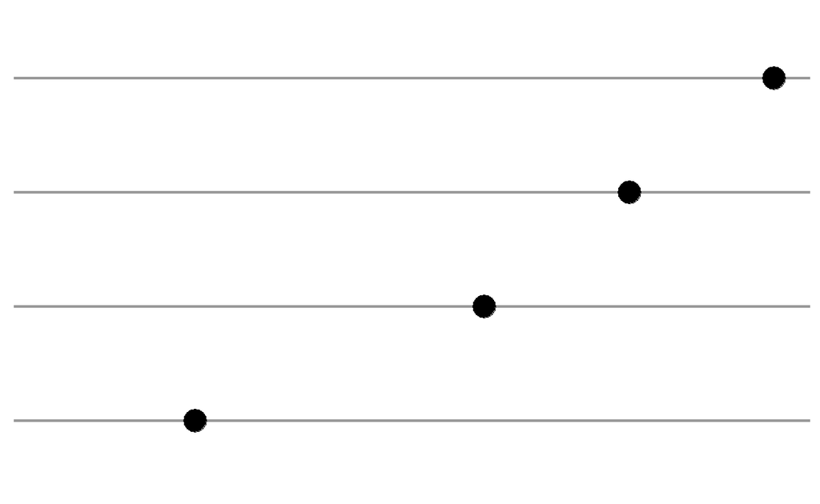

```
my_data <- data.frame(
  grp = c("A", "B", "C", "D"),
  perc = c(1, 0.8, 0.6, 0.2)
)

ggplot(my_data, aes(x = perc, y = reorder(grp, perc))) +
  geom_point(size = 6) +
  scale_x_continuous(breaks = seq(0, 1, 0.2),limits = c(0, 1)) +
  theme_minimal() +
  theme(panel.grid.major.y = element_line(colour = "grey60", size = 0.8),
        panel.grid.major.x = element_blank(),
        panel.grid.minor = element_blank(),
        axis.title.x=element_blank(),
        axis.text.x=element_blank(),
        axis.title.y=element_blank(),
        axis.text.y=element_blank()
  )
```

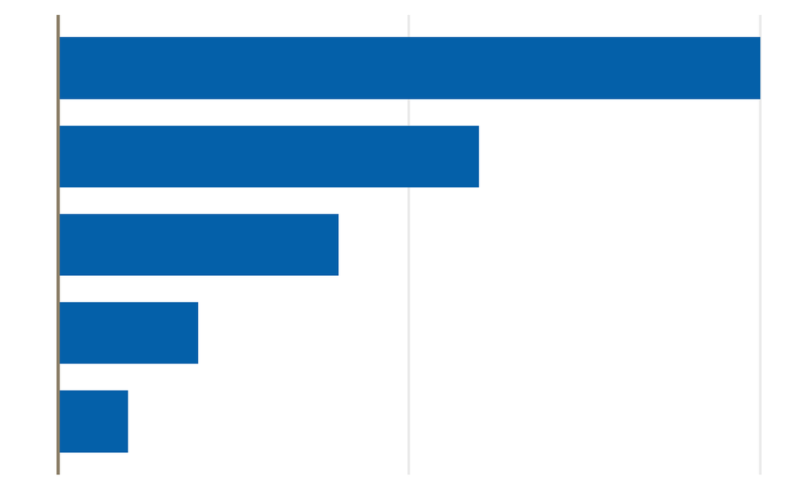

```
df <- data.frame(trt=c("A", "B", "C","D","E"),
                 cause=c(1,2,4,6,10),
                 highlight = c(2,1,2,2,2))


ggplot(df, aes(x=trt, y=cause, group=trt)) + theme_minimal(base_size=18) +
  geom_bar(width=0.7,fill=Novartis.Color.Palette[1,1], stat = "identity") +
  scale_y_continuous(breaks=c(0, 5, 10)) +
  geom_hline(yintercept = 0, colour = "wheat4", linetype=1, size=1)+
  coord_flip() +
  theme(legend.position="none",
        panel.grid.minor.x = element_blank(),
        panel.grid.minor.y = element_blank(),
        panel.grid.major.y = element_blank(),
        axis.ticks = element_blank(),
        axis.title=element_blank(),
        axis.text=element_blank()
  )
```

# Distribution

Histograms, density plots, boxplots and violin plots are common displays for visualising the distribution of a variable.

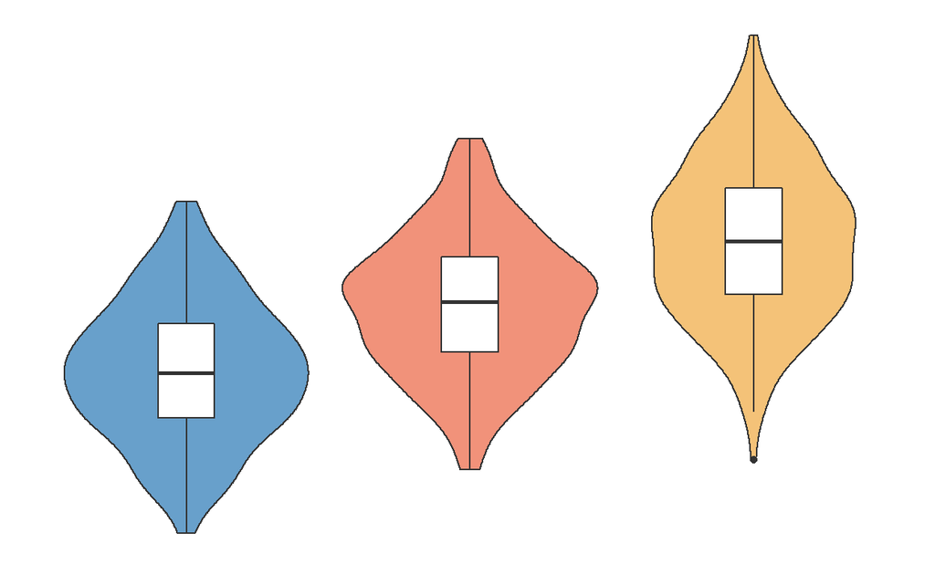

```
### dummy data generation
set.seed(131)

mu1 <- 135.5 # population mean;
sd1 <- 5.5 # sd of population mean across trials
NVS301  <- rnorm(200, mu1, sd1)

mu2 <- 140.1 # population mean;
sd2 <- 5.9 # sd of population mean across trials
NVS201  <- rnorm(200, mu2, sd2)

mu3 <- 145.5 # population mean;
sd3 <- 7 # sd of population mean across trials
SOC101  <- rnorm(200, mu3, sd3)

bp <- c(NVS301,NVS201,SOC101)

trt <- 1:600
trt[1:200] = "NVS301"
trt[201:400] = "NVS201"
trt[401:600] = "SOC101"

trtn <- 1:600
trtn[1:200] = 1
trtn[201:400] = 2
trtn[401:600] = 3


# Put in to simple data frame
dat1 <- data.frame(
  treatment = factor(trt, levels = c("NVS301", "NVS201", "SOC101")),
  bpm = bp
)

ggplot(dat1, aes(x=as.factor(treatment), y=bpm, fill=treatment)) +
  geom_violin(trim=TRUE)+ggFill(color.values=c("Tint1"))+
  geom_boxplot(width=0.2, fill="white")+
  #scale_fill_brewer(palette="RdBu") +
  theme_minimal() +
  theme(legend.position='None',
        panel.grid.minor = element_blank(),
        panel.grid.major = element_blank(),
        axis.ticks.x = element_blank(),
        axis.title=element_blank(),
        axis.text=element_blank(),
        panel.background = element_blank()
  )
```

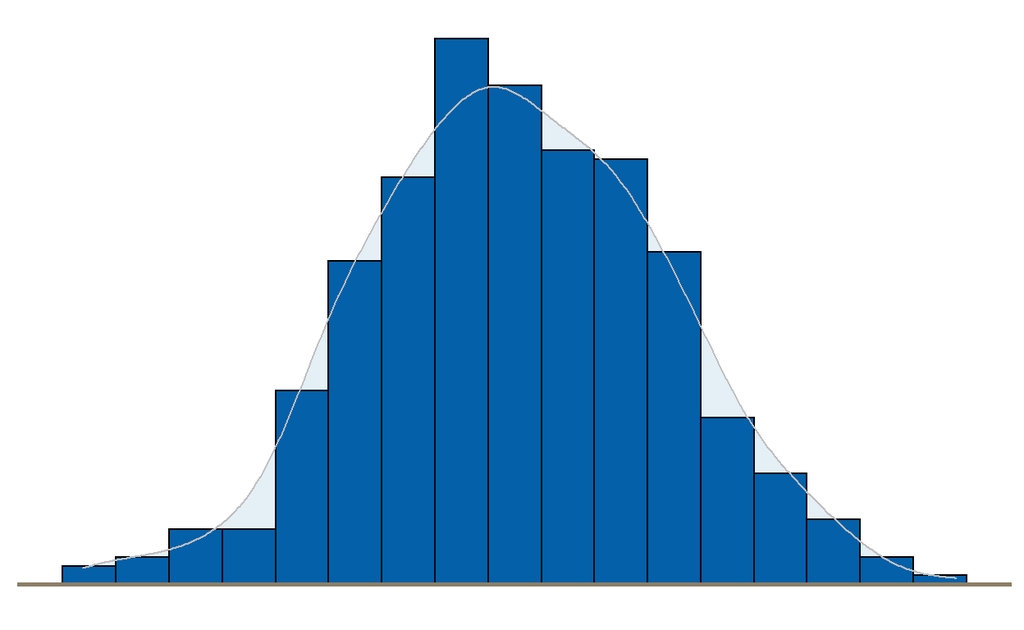

```
set.seed(1234)
dat <- data.frame(cond = factor(rep(c("A","B"), each=200)),
                  rating = c(rnorm(200),rnorm(200, mean=.8)))


# Histogram overlaid with kernel density curve
ggplot(dat, aes(x=rating)) +
  geom_histogram(aes(y=..density..), binwidth=.4,colour="black", fill=Novartis.Color.Palette[1,1]) +
  geom_density(alpha=.1, color = "gray", fill=Novartis.Color.Palette[1,1])+
  geom_hline(yintercept = 0, colour = "wheat4", linetype=1, size=1)+
  theme_minimal() +
  theme(legend.position='None',
        panel.grid.minor = element_blank(),
        panel.grid.major = element_blank(),
        axis.ticks = element_blank(),
        axis.title=element_blank(),
        axis.text=element_blank(),
        panel.background = element_blank(),
        panel.border = element_blank()
  )
```

# Change over time (i.e. evolution)

Line plots can be used for displaying how quantities evolve over time.

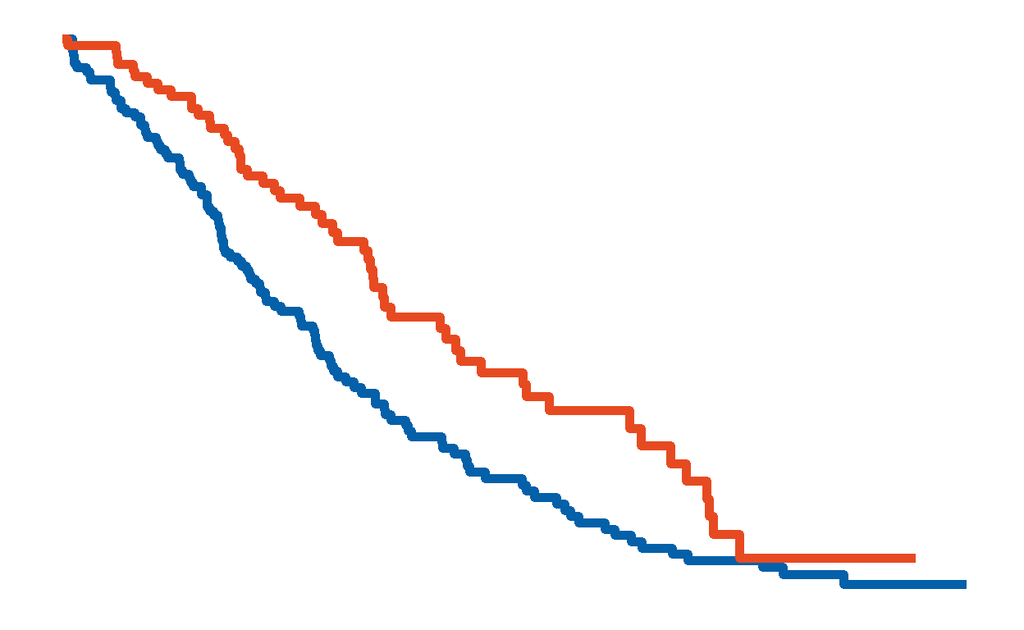

```
fit <- survfit(Surv(time, status) ~ sex, data = lung)
gg<-autoplot(fit, conf.int = FALSE, censor = FALSE, surv.size = 2)
gg + theme_minimal() + ggColor() +
  theme(legend.position='None',
        axis.ticks = element_blank(),
        axis.title=element_blank(),
        axis.text=element_blank(),
        panel.grid.minor = element_blank(),
        panel.grid.major = element_blank(),
        panel.background = element_blank()
  )
```

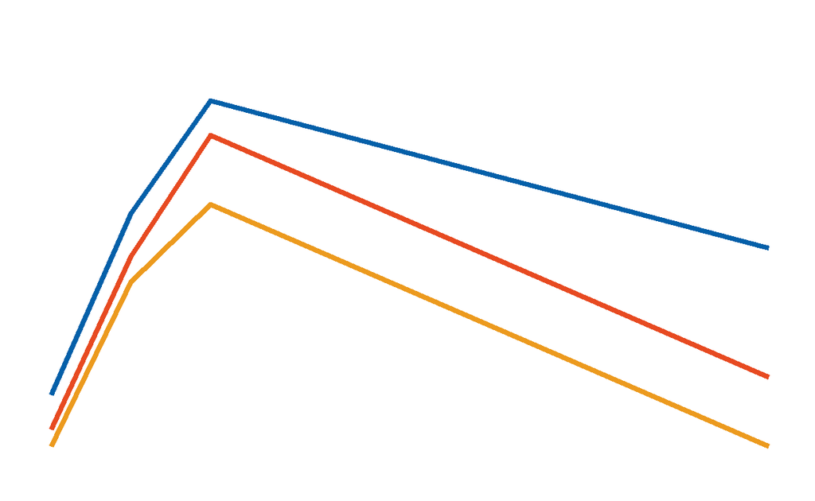

```
#make data
df <- data.frame(trt=rep(c("Dose 1", "Dose 2", "Dose 3"), each=4),
                 visit=rep(c(1, 2, 3, 10),3),
                 response=c(0.8, 2.9, 4.2,2.5, 0.4, 2.4,3.8,1.0,0.2, 2.1,3.0,0.2))
#head(df)

# define a minimal theme
th_con <- theme_minimal(base_size = 12 ) +
  theme(legend.position="none",
        axis.title.y=element_blank(),
        axis.text.y=element_blank(),
        axis.title.x=element_blank(),
        axis.text.x=element_blank(),
        panel.grid.minor=element_blank(),
        panel.grid.major=element_blank()
  )



ggplot(df, aes(x=visit, y=response, group=trt, color = trt)) +
  geom_line(size=1.5) + ggColor() +
  scale_y_continuous(limits = c(0, 5), breaks = c(0,2.5, 5)) +
  th_con
```

# Part-to-whole

For displaying sub‐divisions of a whole (e.g. the percentage of patients in a subgroup), pie charts, bar charts and stacked barcharts can be used.

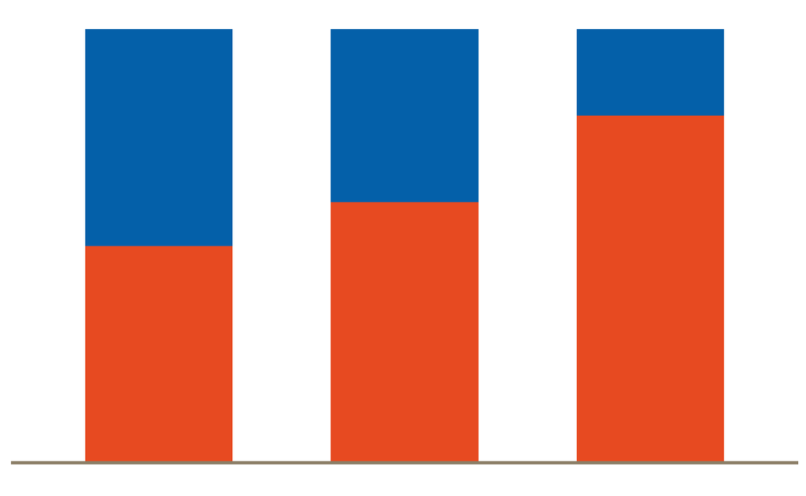

```
# Generate data
df <- data.frame(trt=c("A","A","B", "B","C", "C"),
                 subgroup = c("1","2","1","2","1","2"),
                 percent=c(0.5,0.5,0.4,0.6,0.2,0.8)
)

ggplot(df, aes(x = factor(trt), y = percent, fill = subgroup)) +
  geom_bar(width=0.6, stat="identity") +
  scale_y_continuous(breaks=c(0, 0.5, 1)) + ggFill() +
  #   scale_fill_brewer(palette="Blues") +
  geom_hline(yintercept = 0, colour = "wheat4", linetype=1, size=1)+
  theme_minimal(base_size=9) +
  theme(panel.grid.minor=element_blank(),
        panel.grid.major=element_blank(),
        panel.border=element_blank(),
        axis.ticks = element_blank(),
        axis.text = element_blank(),
        legend.position="none",
        axis.title.x=element_blank(),
        axis.title.y=element_blank())
```

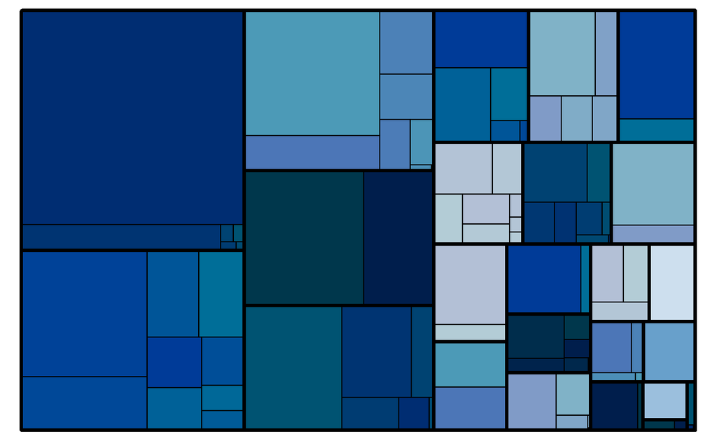

```
data(business)
treemap(business[business$NACE1=="C - Manufacturing",],
        index = c("NACE2","NACE3"), vSize = c("employees"), vColor = c("employees"),
        type = "index", palette = Novartis.Color.Palette[,1], fontsize.labels = 0, fontsize.title = 0)
```

# Magnitude

Dotplots, forest plots and barcharts are useful for displaying comparisons of size or magnitude (i.e. treatment differences)

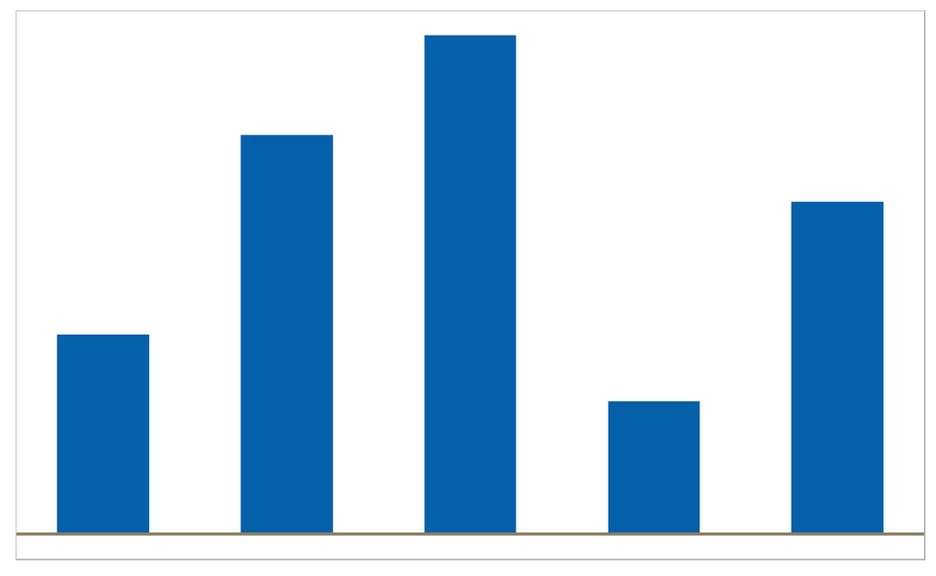

```
df <- data.frame(trt=c("A", "B", "C","D","E"),
                 cause=c(4,6,10,12,15),
                 highlight = c(2,2,2,1,2))

ggplot(df, aes(x=c(4,1,5,2,3), y=cause, group=trt, fill=trt)) +
  geom_bar(width=0.5, stat = "identity") +
  geom_hline(yintercept = 0, colour = "wheat4", linetype=1, size=0.8)+
  ggFill(color.values = "Hue", color.hues = 1) +
  scale_y_continuous(breaks=c(0, 5, 10)) +
  theme(panel.grid.minor=element_blank(),
        panel.grid.major=element_blank(),
        axis.ticks = element_blank(),
        axis.text.y = element_blank(),
        axis.text.x = element_blank(),
        legend.position="none",
        axis.title.x=element_blank(),
        axis.title.y=element_blank())
```

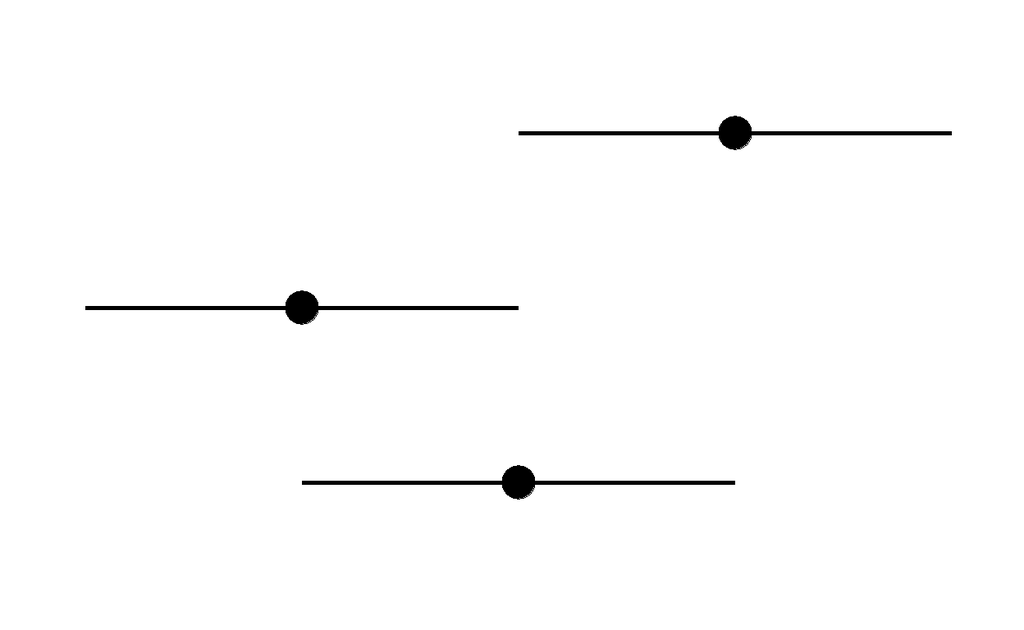

```
theme_set(theme_minimal(base_size=26))
th <- theme(axis.title.x=element_blank(),
            axis.title.y=element_blank(),
            axis.text.x=element_blank(),
            axis.text.y=element_blank(),
            panel.grid.minor=element_blank(),
            panel.grid.major=element_blank()
)


align <- data.frame(x=factor(c(1,2,3)),y=c(2,1,3),low=c(1,0,2),hi=c(3,2,4))
ggplot(align, aes(x=x, y=y, ymin=low, ymax=hi)) +
  geom_point(size=7) +
  geom_linerange(size=1) +
  th +
  coord_flip()
```